# BMS353 - Week 2

November 2020

## Week 1 recap

- Value of reproducibility
- Review of Rstudio and some tidyverse packages

## Week 2 Overview

- Overview of analysing biological data
  - example dataset from older technology
- Define some key steps

## The technology

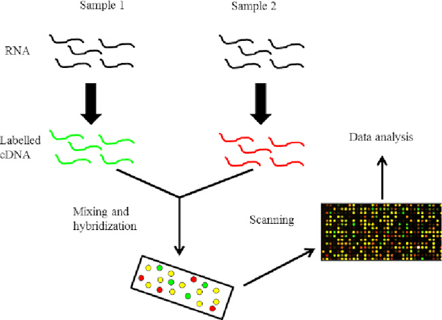

(image uploaded to researchgate by Muhammad Afzal)

## The technology

[figure not shown]

- Illumina HT-12 chip
- 12 samples; 48,000 probes

## Microarrays vs RNA-seq

- Require DNA sequences (probes) to be designed ahead of time
- The probes could be incorrectly designed
  - the genome changes over time; the probes do not
  - ~50% might not actually target the correct regions!
- Don’t permit novel discoveries
- Difficult to detect lowly-expressed transcripts

## Microarrays vs RNA-seq

- RNA-seq permits whole transcriptome to be profiled
- Data can be re-analysed with different genome versions (future-proof)
- Costs initially prohibitively higher, but have reduced dramatically
- Much larger volume of data (initially) but comparable once pre-processed (aligned)
- New computational methods were required, but these are established now
- Many key principles apply
  - experimental design
  - quality assessment
  - statistical testing

## Data availability

- Vast amount of data available in public *repositories*
  - Gene Expression Omnibus (GEO)
  - ArrayExpress
- Relatively quick and easy to validate hypotheses

## Multi-dimensional data

- Once downloaded the data are not in a straightforward form that we are used to
- Separate data frames
  - expression measurements (the *assay* data)
  - sample annotation (the *meta* data)
  - feature annotation
- Hence the need for specialised packages

## Multi-dimensional data

Say we have interrogated **10,000** genes for **10** patients

- the expression matrix will have **10,000** rows and **10** columns
- the sample annotation will have **10** rows and arbitrary number of columns
  - age of patient, gender, disease state
  - experiment batch, date collected
- the feature annotation will have **10,000** rows and arbitrary number of columns
  - probe identifier
  - common gene name, ensembl name, genome position

## Workflow overview

- quality assessment
  - did the experiment work? any batch effects
- normalisation
  - adjust for technical variation
- statistical testing
  - which genes have evidence for change between groups

## Quality assessment

- samples should exhibit roughly the same *distribution* of intensities
- any difference between sample run on different *batches*?
- any *outliers*?
- Assessed by a boxplot (among other methods)

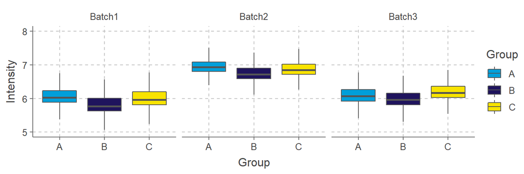

## Normalisation

- correct for technical and non-interesting variation between samples
- tend to assume that **most genes don’t change** between samples
- assume that distribution is highly-similar
  - quantile normalisation forces distributions to be identical

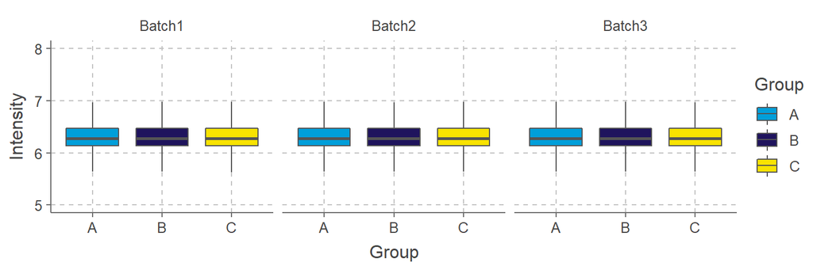

## Statistical Testing

- which genes show evidence for different expression between sample groups
- large number of genes, generally few samples
- make assumptions about data distribution
  - assume *normal* so can use a t-statistic
- need to correct for *multiple testing*

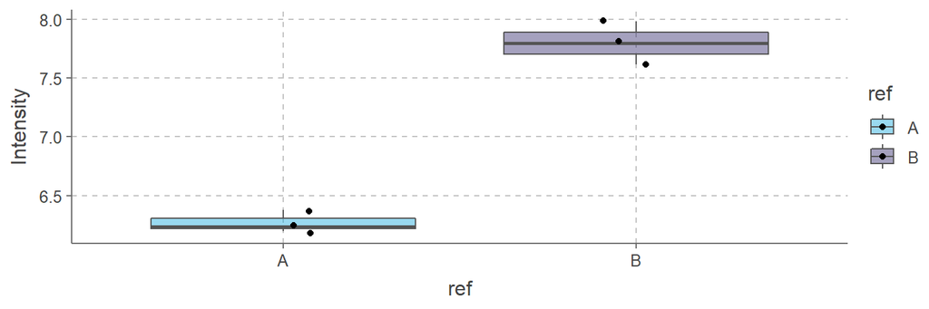

## Further viewing

- [Gene Expression Analysis and DNA microarray Assays](https://youtu.be/Hv5flUOsE0s) - 8 minutes
- [Quantile Normalisation for high-throughput Biology](https://youtu.be/ecjN6Xpv6SE) - 5 minutes
- [Statistics for Genomics](https://youtu.be/3huF0DwxCtU) - 30 minutes
- [Multiple Testing Correction](https://youtu.be/K8LQSvtjcEo) - 18 minutes